# Activision Blizzard Stock Time Series Analysis

Jeffrey Li

November 20, 2018

```r
rm(list = ls())
library(quantmod)
library(forecast)
library(ggplot2)
library(scales)
theme_set(theme_minimal())
library(gridExtra)
library(dygraphs)
library(tseries)
library(ggfortify)
library(TTR)
library(kableExtra)

start <- as.Date("2017-05-22")
end <- as.Date("2018-11-30")
suppressWarnings(getSymbols("ATVI", src = "yahoo", from = start, to = end))
```

```
## [1] "ATVI"
```

```r
ATVI_df <- as.data.frame(ATVI)
ATVI_df<- cbind(Date=as.Date(rownames(ATVI_df)),ATVI_df)

nrow(ATVI)
```

```
## [1] 386
```

```r
acc_table <- data.frame()

forecast_len <- floor(0.1*(nrow(ATVI)))
```

A summary of the Activision Blizzard stock.

```r
summary(ATVI)
```

```
##      Index              ATVI.Open       ATVI.High        ATVI.Low
##  Min.   :2017-05-22   Min.   :47.77   Min.   :49.91   Min.   :46.83
##  1st Qu.:2017-10-06   1st Qu.:62.41   1st Qu.:63.15   1st Qu.:61.74
##  Median :2018-02-26   Median :66.61   Median :67.44   Median :65.53
##  Mean   :2018-02-24   Mean   :67.58   Mean   :68.40   Mean   :66.62
##  3rd Qu.:2018-07-15   3rd Qu.:72.50   3rd Qu.:73.31   3rd Qu.:71.31
##  Max.   :2018-11-29   Max.   :84.18   Max.   :84.68   Max.   :82.74
##    ATVI.Close     ATVI.Volume       ATVI.Adjusted
##  Min.   :49.14   Min.   : 1644700   Min.   :49.14
##  1st Qu.:62.41   1st Qu.: 4688600   1st Qu.:62.09
##  Median :66.34   Median : 5723350   Median :66.29
##  Mean   :67.54   Mean   : 6603749   Mean   :67.35
##  3rd Qu.:72.36   3rd Qu.: 7589275   3rd Qu.:72.09
##  Max.   :83.39   Max.   :34543400   Max.   :83.39
```

There are 386 data entries.

Check for anyNA values.

```r
anyNA(ATVI)
```

```
## [1] FALSE
```

Transforming the xts to a timeseries (ts).

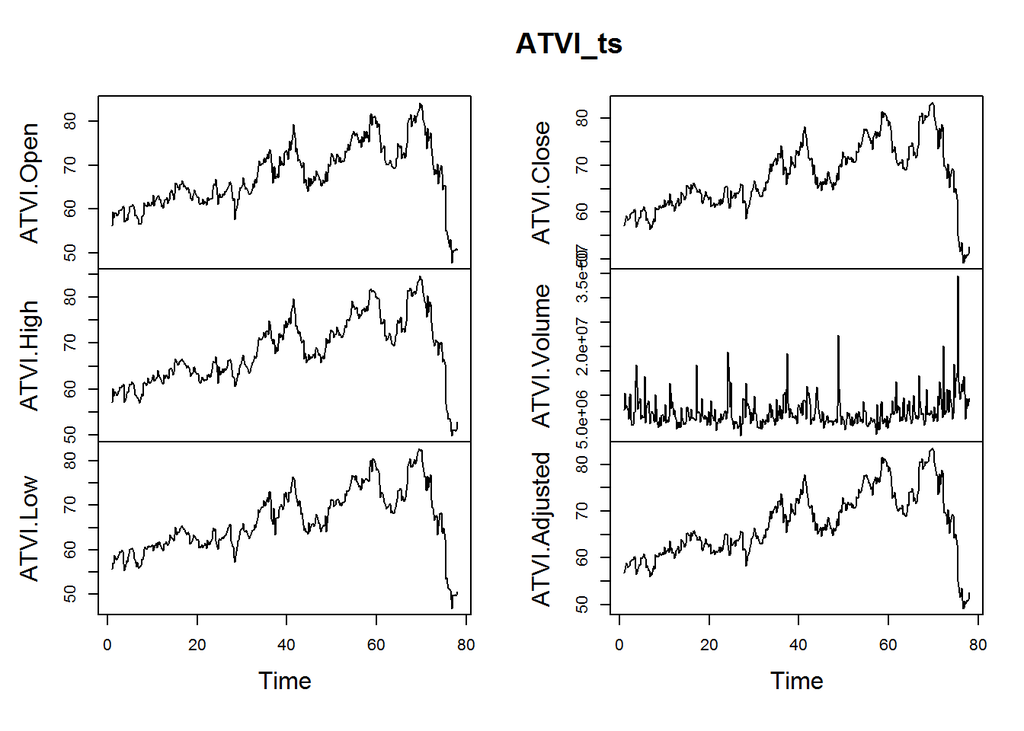

```r
ATVI_ts <- ts(ATVI, frequency = 5)
plot(ATVI_ts)
```

Looking at univariate distributions of the stocks.

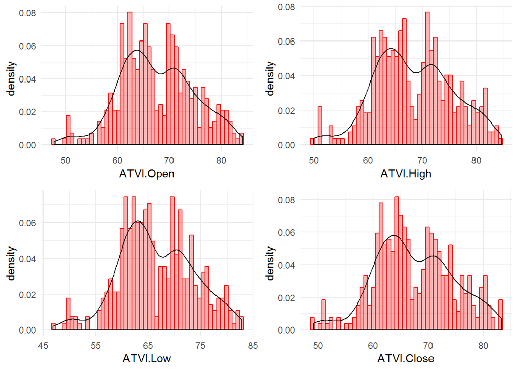

```r
par(mfrow = c(2,2))
uni_open <- ggplot(ATVI, aes(ATVI.Open)) + geom_histogram(bins = 50, aes(y = ..density..), col = "red", fill = "red", alpha = 0.3) + geom_density()

uni_high <- ggplot(ATVI, aes(ATVI.High)) + geom_histogram(bins = 50, aes(y = ..density..), col = "red", fill = "red", alpha = 0.3) + geom_density()

uni_low <- ggplot(ATVI, aes(ATVI.Low)) + geom_histogram(bins = 50, aes(y = ..density..), col = "red", fill = "red", alpha = 0.3) + geom_density()

uni_close <- ggplot(ATVI, aes(ATVI.Close)) + geom_histogram(bins = 50, aes(y = ..density..), col = "red", fill = "red", alpha = 0.3) + geom_density()

grid.arrange(uni_open, uni_high, uni_low, uni_close, nrow = 2, ncol = 2)
```

```r
average_price = sum(ATVI_df$ATVI.Open + ATVI_df$ATVI.Close)/(2*nrow(ATVI))
```

It seems historically the majority of prices for the ATVI stock has been around 67.56 USD. The density plots are left skewed and have a bimodal distribution.

Visualizing the closing stock prices.

```r
dygraph(ATVI_df[,c("ATVI.Open","ATVI.Close")], xlab = "Time", ylab = "Price in USD", main = "Activision Blizzard, Inc. Opening and Closing Stock Price") %>% dyOptions(colors = c(rgb(57,106,177, maxColorValue = 255), rgb(218,124,48, maxColorValue = 255)))
```

[interactive chart not shown]

The peak closing price of 83.389999 USDand the lowest recorded closing price of 49.139999.

Visualizing the daily stock returns.

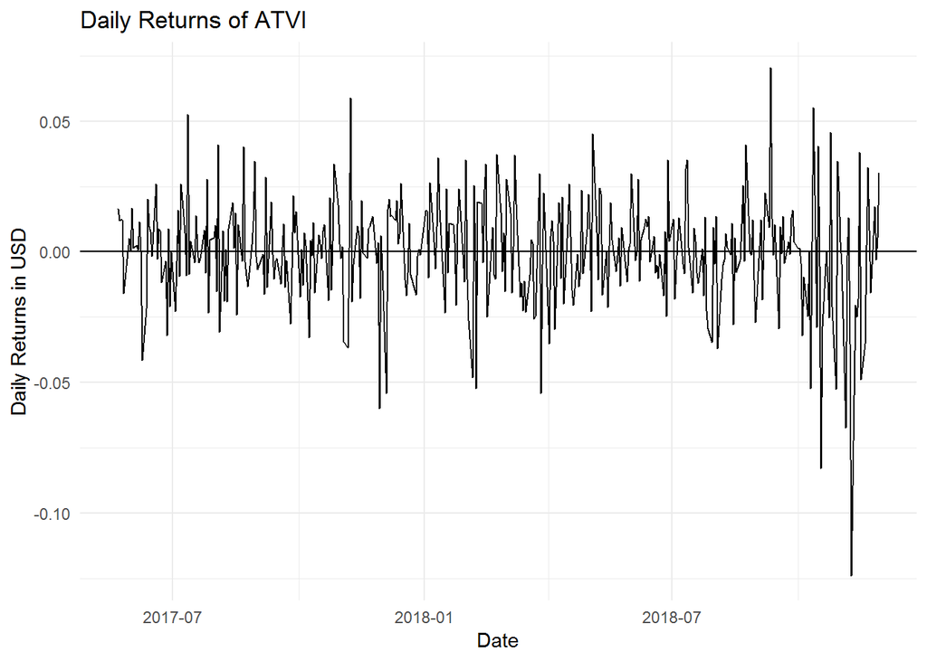

```r
ATVI_return <- dailyReturn(ATVI)
ATVI_return <- as.data.frame(ATVI_return)
ATVI_return <- cbind(Date=as.Date(rownames(ATVI_return)),ATVI_return)
ggplot(ATVI_return, aes(x = Date, y = daily.returns)) + geom_path() + geom_hline(yintercept = 0) + ggtitle("Daily Returns of ATVI") + ylab("Daily Returns in USD")
```

```r
mean_return <- mean(ATVI_return[,2])
```

The average daily return is 0.00004917699.

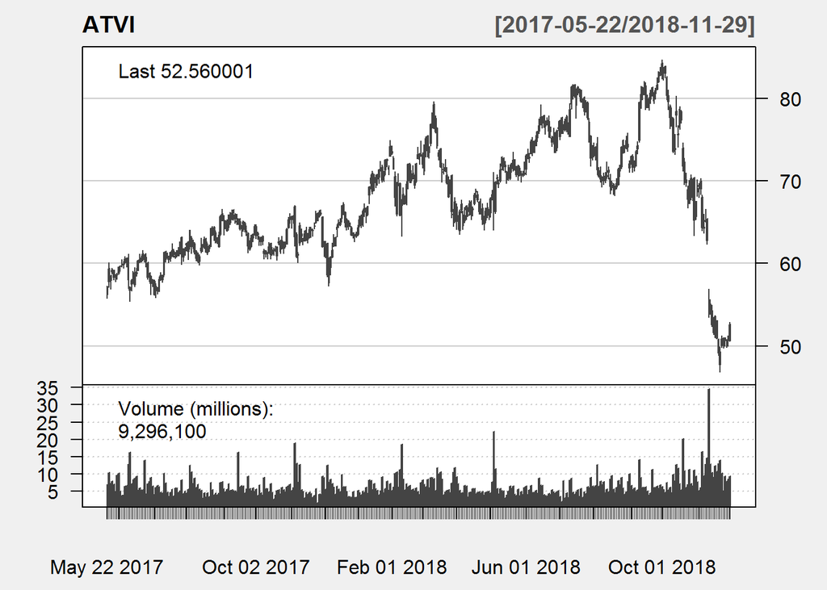

```r
candleChart(ATVI, up.col = "black", dn.col = "red", theme = "white")
```

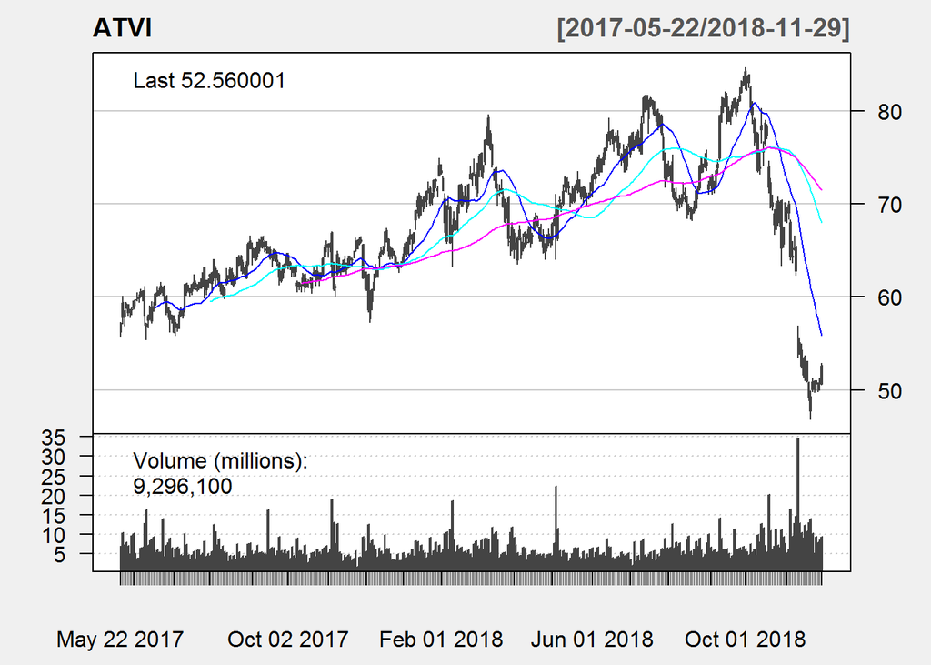

```r
addSMA(n = c(20, 50, 100))
```

Looking at the 20-day moving average (dark blue) the stock needs to be above or below for the slope of the line to change directions. This can possibly be used to identify a change in trend and can be seen as trading signals. The 50-day moving average (light blue) indicates that the stock switches between a bearish and bullish trend but overall was rising. The 100-day moving average (pink) indicated that the stock in the long run was increasing but near November the stock starts to trend downwards.

# Decomposing the data

Decomposing the ATVI time series using both a additive and multiplicative model.

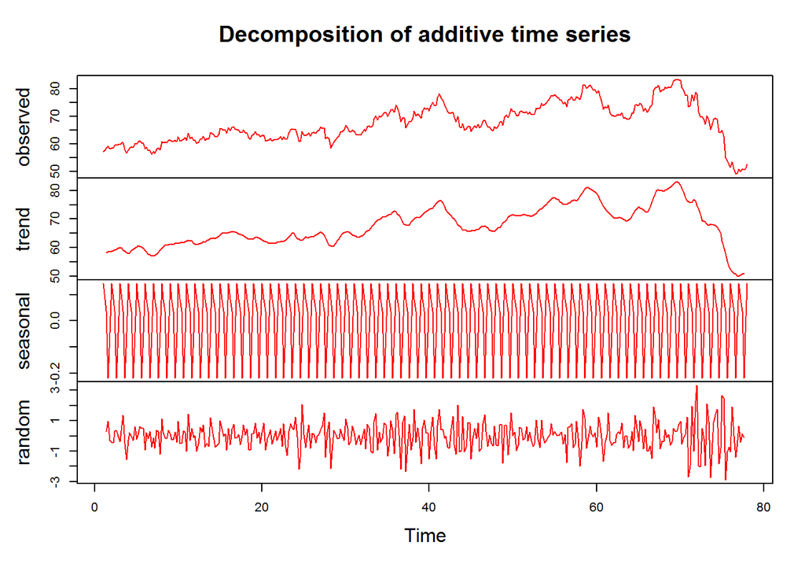

```r
ATVI_add <- decompose(ATVI_ts[,"ATVI.Close"], type = "additive")
ATVI_mul <- decompose(ATVI_ts[,"ATVI.Close"], type = "multiplicative")

plot(ATVI_add, col = "red")
```

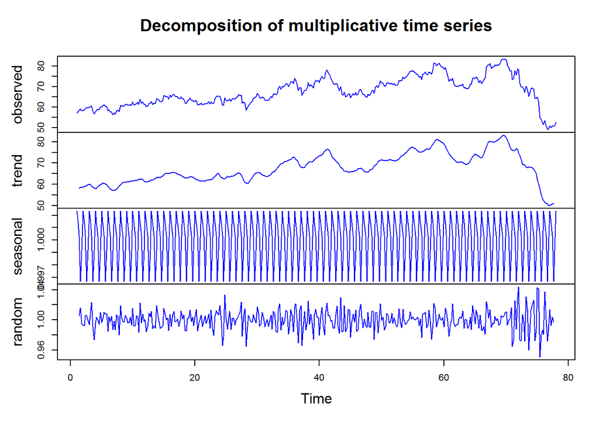

```r
plot(ATVI_mul, col = "blue")
```

The additive and multiplicative models are very similary with slight differences in the seasonal and random elements.

# Stationarity

Checking for stationarity is important as it is an assumption for many underlying tools for time series analysis.

```r
adf.test(ATVI$ATVI.Close, k = 11)
```

```
##
##  Augmented Dickey-Fuller Test
##
## data:  ATVI$ATVI.Close
## Dickey-Fuller = -1.2102, Lag order = 11, p-value = 0.9041
## alternative hypothesis: stationary
```

```r
kpss.test(ATVI$ATVI.Close, lshort = FALSE, null = "Trend")
```

```
##
##  KPSS Test for Trend Stationarity
##
## data:  ATVI$ATVI.Close
## KPSS Trend = 0.19081, Truncation lag parameter = 14, p-value =
## 0.01945
```

A stationary process has mean and variance that do not change with time and the process does not have trend. The Augmented Dickey-Fuller Test tests the null hypothesis that a unit root is present in the time series and the alternative hypothesis is that the time series is stationary or trend-stationary.  
The Kwiatkowski–Phillips–Schmidt–Shin (KPSS) test is used for testing the null hypothesis that the time series is stationary and has a deterministic trend; the alternative hypothesis is that there is a unit root.  
Both tests point to the time series not being stationary; we fail to reject the null hypothesis for the ADF test and we reject the null hypothesis of the KPSS test, both at 5% level at significance.

# Differencing

```r
diff_ATVI_close <- diff(ATVI_ts[,"ATVI.Close"], differences = 1)
suppressWarnings(adf.test(diff_ATVI_close, k = 11))
```

```
##
##  Augmented Dickey-Fuller Test
##
## data:  diff_ATVI_close
## Dickey-Fuller = -5.1559, Lag order = 11, p-value = 0.01
## alternative hypothesis: stationary
```

```r
suppressWarnings(kpss.test(diff_ATVI_close, lshort = FALSE, null = "Trend"))
```

```
##
##  KPSS Test for Trend Stationarity
##
## data:  diff_ATVI_close
## KPSS Trend = 0.087797, Truncation lag parameter = 14, p-value =
## 0.1
```

```r
diff_ATVI_close2 <- diff(ATVI_ts[,"ATVI.Close"], differences = 2)

diff_adf <- (adf.test(diff_ATVI_close2, k = 11))
diff_adf
```

```
##
##  Augmented Dickey-Fuller Test
##
## data:  diff_ATVI_close2
## Dickey-Fuller = -9.663, Lag order = 11, p-value = 0.01
## alternative hypothesis: stationary
```

```r
(kpss.test(diff_ATVI_close2, lshort = FALSE, null = "Trend"))
```

```
##
##  KPSS Test for Trend Stationarity
##
## data:  diff_ATVI_close2
## KPSS Trend = 0.020954, Truncation lag parameter = 13, p-value =
## 0.1
```

We have chosen the significance level $alpha$ = 5% or 0.05. Here we reject the the null hypothesis for the ADF test since the p-value < 0.01 which is less than 0.05. In addition we can look at the Dicker-Fuller statistic of -9.6629905 and we compare this to the critical values for Dickey–Fuller t-distribution table[^1], we observe that the ADF test statistic is less than -3.43 and the null hypothesis of a unit root is rejected. We accept the null hypothesis of the KPSS test since the p-value is larger than 0.1. Therefore we can say the timeseries is stationary when differenced twice.

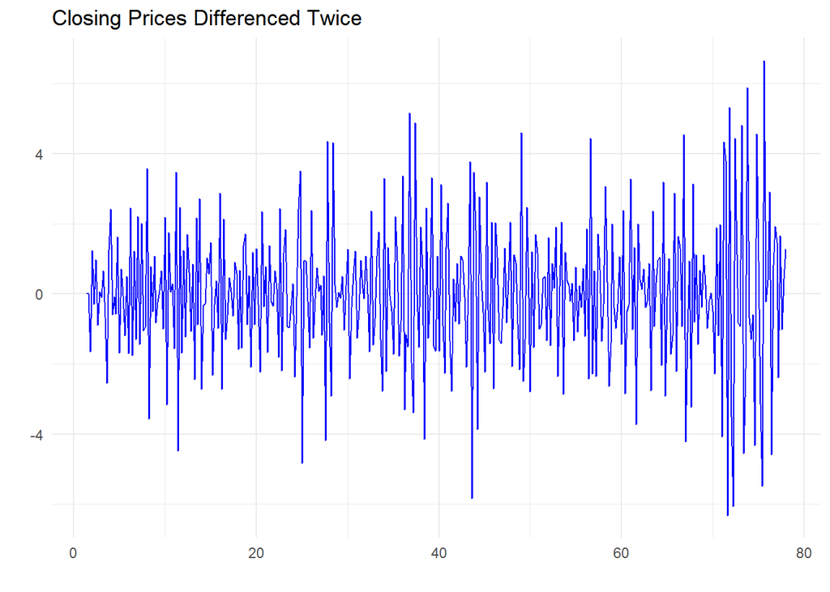

```r
autoplot(diff_ATVI_close2, ts.colour = "blue", main = "Closing Prices Differenced Twice")
```

# Simple Exponential Smoothing (SES)

Simple exponential smoothing utilizes weights to forecast future values by assigning weights to observations. The more recent the observation the higher the weight.

Creating a training and data subset of the timeseries to see how well the SES model is at forecasting.

```r
start <- floor(0.8*(nrow(ATVI)))
test_ahead <- (nrow(ATVI) - start)
ATVI_window <- window(ts(ATVI_ts[,"ATVI.Close"]), end = floor(0.8*(nrow(ATVI))))

ATVI_SES <- HoltWinters(ATVI_window, beta = FALSE, gamma = FALSE)
ATVI_SES
```

```
## Holt-Winters exponential smoothing without trend and without seasonal component.
##
## Call:
## HoltWinters(x = ATVI_window, beta = FALSE, gamma = FALSE)
##
## Smoothing parameters:
##  alpha: 0.885945
##  beta : FALSE
##  gamma: FALSE
##
## Coefficients:
##       [,1]
## a 70.44766
```

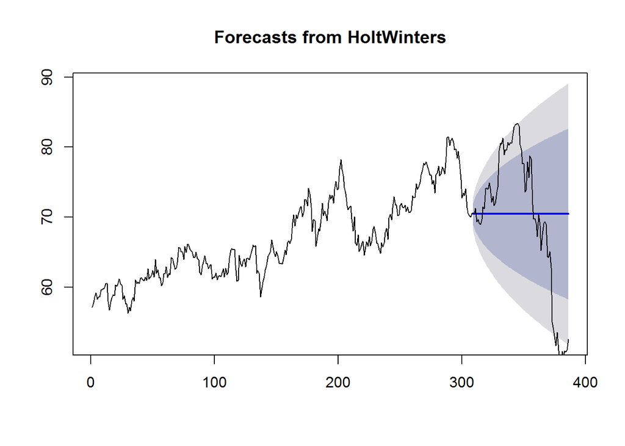

```r
ATVI_forecast <- forecast(ATVI_SES, h = test_ahead)
#ATVI_forecast

plot(ATVI_forecast)
lines(ts(ATVI_ts[,"ATVI.Close"]))
```

```r
acc_table <- rbind(accuracy(ATVI_forecast$fitted, ATVI_ts[,"ATVI.Close"][191:255]), acc_table)
```

Forecasting values in the future using Simple Exponential Smoothing.

```r
ATVI_SES1 <- HoltWinters(ATVI_ts[,"ATVI.Close"], beta = FALSE, gamma = FALSE)
ATVI_SES1
```

```
## Holt-Winters exponential smoothing without trend and without seasonal component.
##
## Call:
## HoltWinters(x = ATVI_ts[, "ATVI.Close"], beta = FALSE, gamma = FALSE)
##
## Smoothing parameters:
##  alpha: 0.9678723
##  beta : FALSE
##  gamma: FALSE
##
## Coefficients:
##       [,1]
## a 52.51025
```

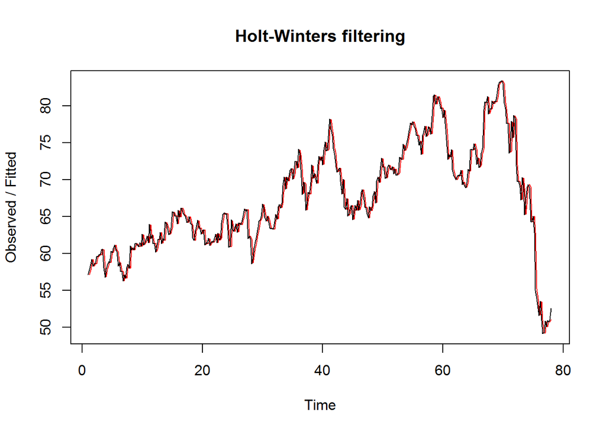

```r
plot(ATVI_SES1)
```

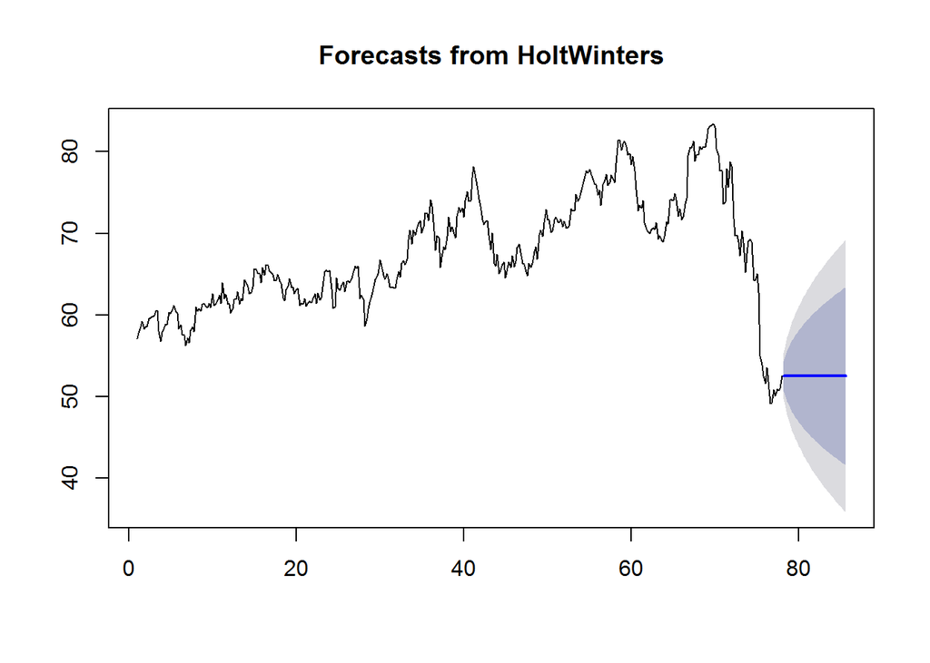

```r
ATVI_forecast1 <- forecast(ATVI_SES1, h = forecast_len)
#ATVI_forecast
plot(ATVI_forecast1)
```

Looking at the residuals on the forecast.

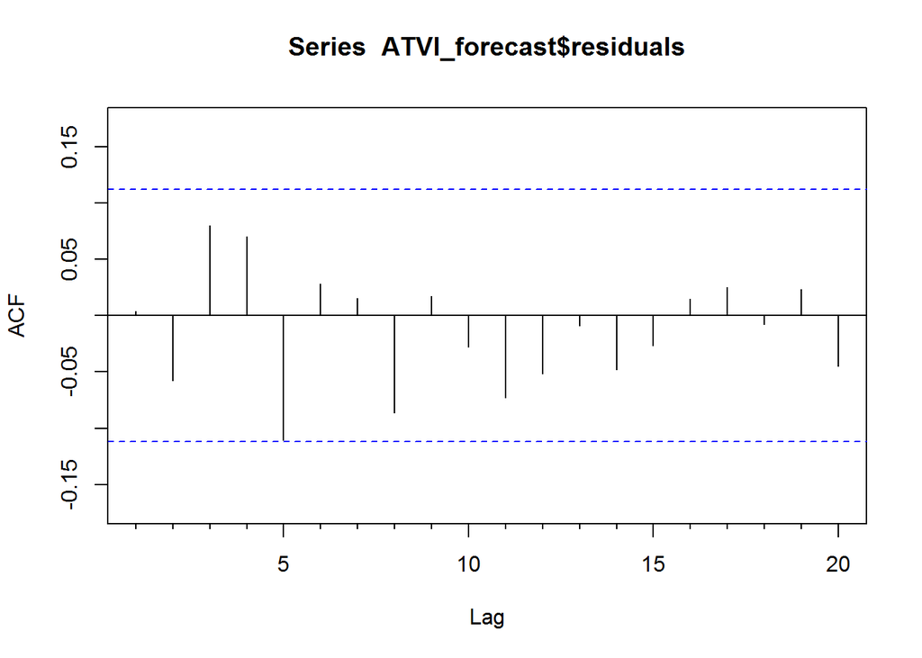

```r
ATVI_fc1_acf <- Acf(ATVI_forecast$residuals, lag.max=20)
```

```r
ATVI_boxtest1 <- Box.test(ATVI_forecast$residuals, lag=20, type="Ljung-Box")
ATVI_boxtest1
```

```
##
##  Box-Ljung test
##
## data:  ATVI_forecast$residuals
## X-squared = 16.157, df = 20, p-value = 0.7068
```

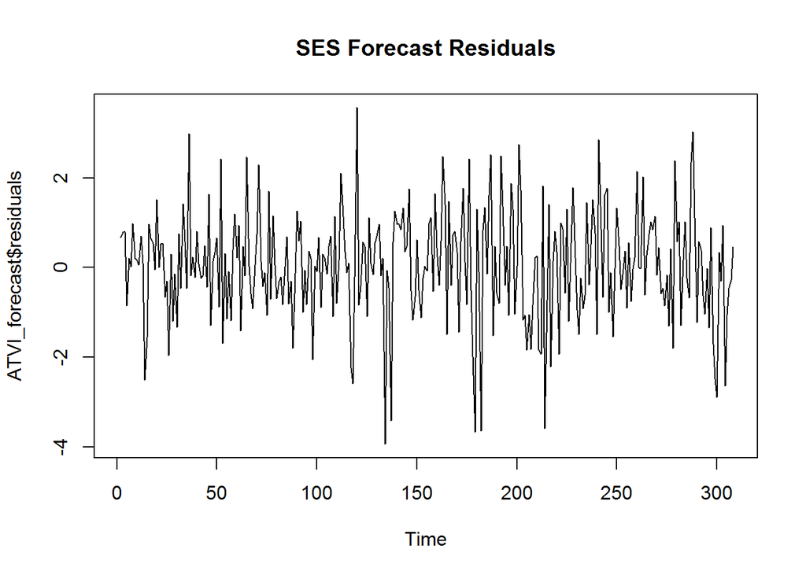

```r
plot.ts(ATVI_forecast$residuals, main = "SES Forecast Residuals")
```

From the autocorrelcation function plot only 1 out of the 20 lags are out of significance bounds. The p-value from the BoxLjung test is 0.7068, this indicates that there is little evidence of non-zero autocorrelations in the in-sample forecast errors at lags 1-20.

# Holt-Winters Exponential Smoothing (HWES)

Holt-Winters Exponential smoothing is an exponentially weighted moving average filter of the level, trend, and seasonal components of a time series. The parameters used for smoothing are chosen by minimizing the sum of the squared one-step-ahead-prediction errors.

Creating a training and data subset of the timeseries to see how well the Holt-Winters Exponential Smoothing model is at forecasting.

```r
suppressWarnings(ATVI_hw <- HoltWinters(ATVI_window, gamma = FALSE))
ATVI_hw
```

```
## Holt-Winters exponential smoothing with trend and without seasonal component.
##
## Call:
## HoltWinters(x = ATVI_window, gamma = FALSE)
##
## Smoothing parameters:
##  alpha: 0.8965743
##  beta : 0.03041517
##  gamma: FALSE
##
## Coefficients:
##         [,1]
## a 70.4360972
## b -0.1229162
```

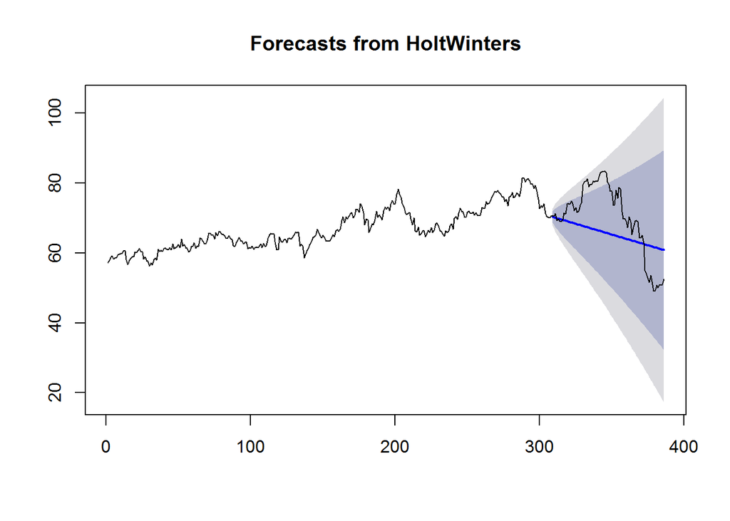

```r
ATVI_forecast2 <- forecast(ATVI_hw, h = test_ahead)
plot(ATVI_forecast2)
lines(ts(ATVI_ts[,"ATVI.Close"]))
```

```r
acc_table <- rbind(accuracy(ATVI_forecast2$fitted, ATVI_ts[,"ATVI.Close"][191:255]), acc_table)
```

```r
ATVI_hw2 <- HoltWinters(ATVI_ts[,"ATVI.Close"], gamma = FALSE)
ATVI_hw2
```

```
## Holt-Winters exponential smoothing with trend and without seasonal component.
##
## Call:
## HoltWinters(x = ATVI_ts[, "ATVI.Close"], gamma = FALSE)
##
## Smoothing parameters:
##  alpha: 0.9590403
##  beta : 0.02620724
##  gamma: FALSE
##
## Coefficients:
##         [,1]
## a 52.4781388
## b -0.3784137
```

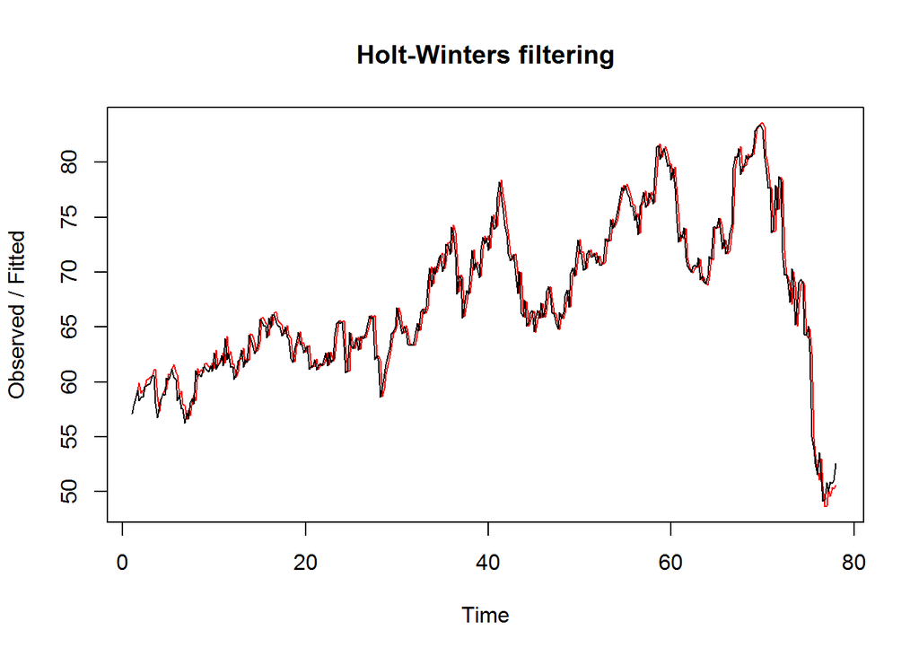

```r
plot(ATVI_hw2)
```

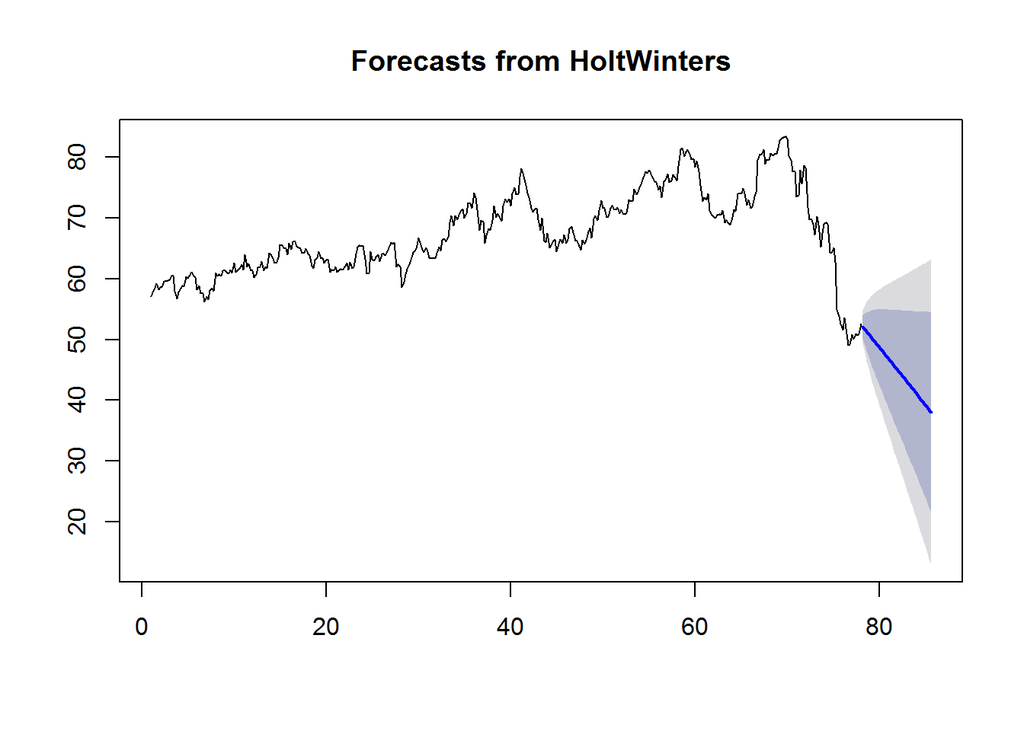

```r
ATVI_forecast2 <- forecast(ATVI_hw2, h =  forecast_len)
#ATVI_forecast2
plot(ATVI_forecast2)
```

The estimated values of alpha and beta are 0.959 and 0.0262. The value of alpha is high indicating that the estimate of the level at the time T is based upon more recent observations rather than observations further in the past. The value of beta is rather small and points towards the older values being weighted more heavily than the recent ones when determining the slope. There is no gamma component due to the lack of seasonality within the data.

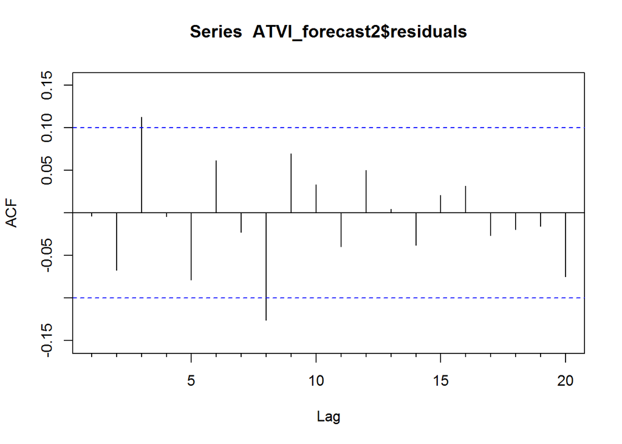

```r
ATVI_fc2_acf <- Acf(ATVI_forecast2$residuals, lag.max=20)
```

```r
ATVI_boxtest2 <- Box.test(ATVI_forecast2$residuals, lag=20, type="Ljung-Box")
ATVI_boxtest2
```

```
##
##  Box-Ljung test
##
## data:  ATVI_forecast2$residuals
## X-squared = 24.979, df = 20, p-value = 0.2022
```

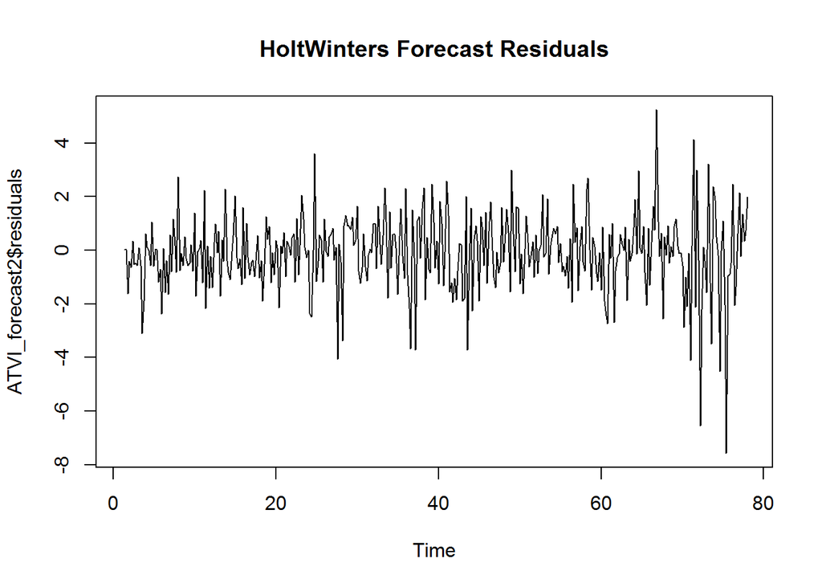

```r
plot.ts(ATVI_forecast2$residuals, main = "HoltWinters Forecast Residuals")
```

The autocorrelation plot has two and possibly three lags that are out of the significance bounds. The p-value from the Box-Ljung test is 0.2022, this indicates that there is little evidence of non-zero autocorrelations in the in-sample forecast errors at lags 1-20.

# Autoregressive integrated moving average (ARIMA) model

We must now see if the model is an AR or MA process. This can be done using by looking at the plots of acf() and pacf() .

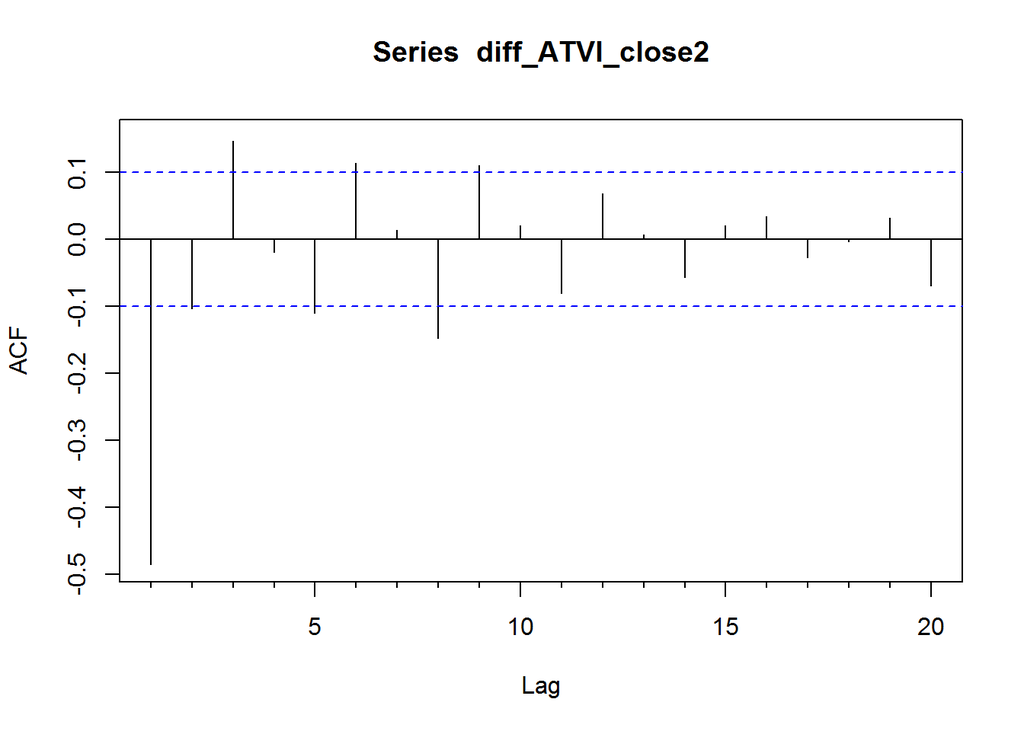

```r
close_acf <- Acf(diff_ATVI_close2, lag = 20)
```

```r
close_acf
```

```
##
## Autocorrelations of series 'diff_ATVI_close2', by lag
##
##      0      1      2      3      4      5      6      7      8      9
##  1.000 -0.486 -0.103  0.147 -0.020 -0.110  0.114  0.013 -0.148  0.111
##     10     11     12     13     14     15     16     17     18     19
##  0.021 -0.081  0.068  0.007 -0.057  0.020  0.035 -0.027 -0.004  0.032
##     20
## -0.069
```

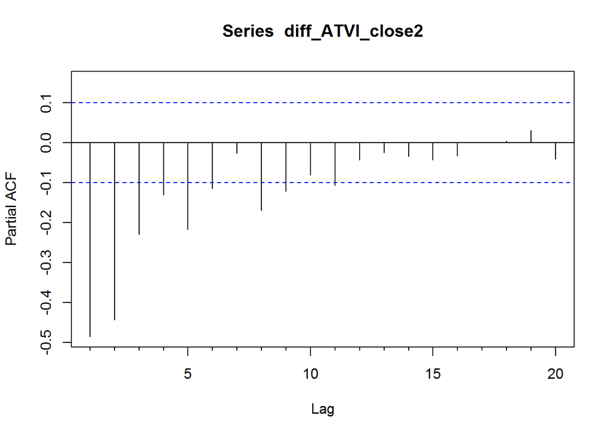

```r
close_pacf <- Pacf(diff_ATVI_close2, lag = 20)
```

```r
close_pacf
```

```
##
## Partial autocorrelations of series 'diff_ATVI_close2', by lag
##
##      1      2      3      4      5      6      7      8      9     10
## -0.486 -0.444 -0.230 -0.131 -0.217 -0.115 -0.026 -0.169 -0.121 -0.081
##     11     12     13     14     15     16     17     18     19     20
## -0.107 -0.043 -0.025 -0.035 -0.043 -0.032  0.000  0.005  0.031 -0.040
```

Looking at the ACF and PACF gives us p = 5,6,8 and q = 3.

Using the auto.arima() function with d=2 for the number of times the data needed to be differenced to obtain stationarity.

```r
auto.arima(ATVI_ts[,4], d=2, seasonal = FALSE)
```

```
## Series: ATVI_ts[, 4]
## ARIMA(0,2,2)
##
## Coefficients:
##           ma1     ma2
##       -1.0267  0.0372
## s.e.   0.0538  0.0543
##
## sigma^2 estimated as 2.044:  log likelihood=-683.11
## AIC=1372.22   AICc=1372.28   BIC=1384.07
```

Testing the accuracy of the arima(3,2,1)

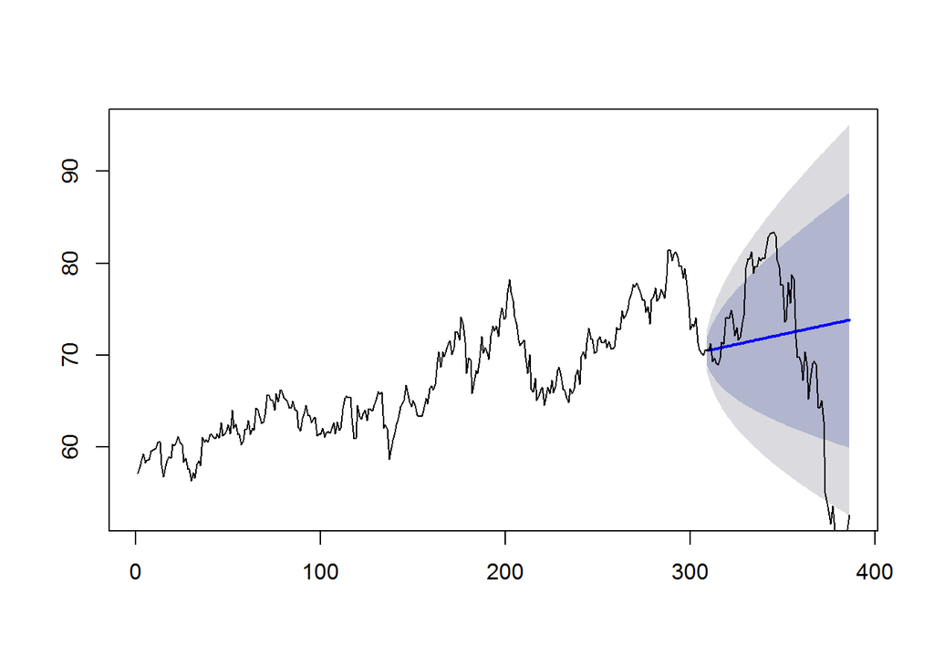

```r
fit_no_holdout = arima(ATVI_window, order=c(3,2,1))

fcast_no_holdout <- forecast(fit_no_holdout, h = test_ahead)
plot(fcast_no_holdout, main=" ")
lines(ts(ATVI_ts[,"ATVI.Close"]))
```

```r
acc_table <- rbind(accuracy(fcast_no_holdout$fitted, ATVI_ts[,"ATVI.Close"][191:255]), acc_table)
```

Fitting an arima(3,2,1) to forecast.

```r
fit <- arima(ATVI_ts[,4], order = c(3,2,1))
fit
```

```
##
## Call:
## arima(x = ATVI_ts[, 4], order = c(3, 2, 1))
##
## Coefficients:
##           ar1      ar2     ar3      ma1
##       -0.0256  -0.0566  0.1207  -0.9916
## s.e.   0.0517   0.0515  0.0515   0.0113
##
## sigma^2 estimated as 1.996:  log likelihood = -679.61,  aic = 1369.23
```

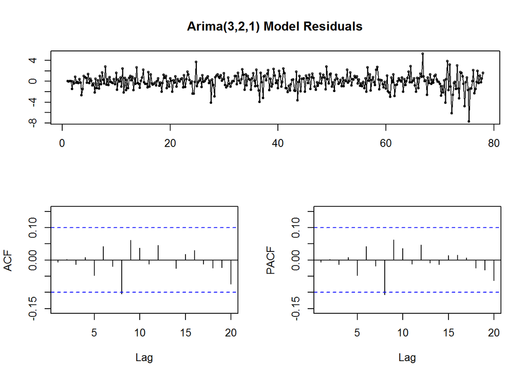

```r
tsdisplay(residuals(fit), lag.max=20, main = "Arima(3,2,1) Model Residuals")
```

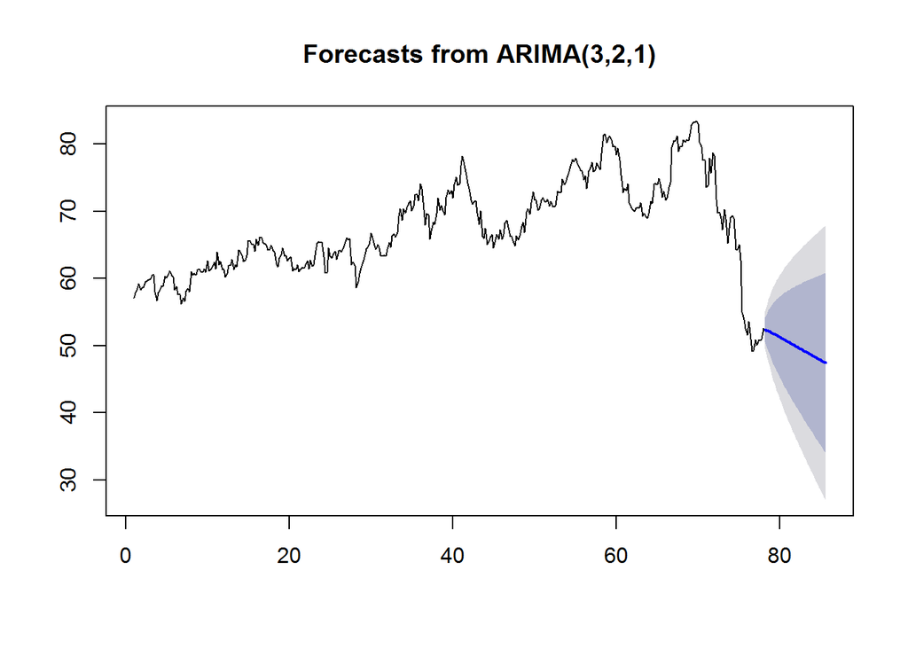

```r
ATVI_fcast <- forecast(fit, h= forecast_len)
plot(ATVI_fcast, main = "Forecasts from ARIMA(3,2,1)")
```

Testing the ARIMA model using p and q from our visual analysis of the Acf and Pacf.

```
##
## Call:
## arima(x = ATVI_ts[, 4], order = c(5, 2, 3))
##
## Coefficients:
##           ar1      ar2     ar3     ar4     ar5      ma1      ma2      ma3
##       -0.8767  -0.8201  0.0463  0.0575  0.0138  -0.1313  -0.0886  -0.7553
## s.e.   0.1919   0.1739  0.0848  0.0852  0.0681   0.1843   0.1761   0.1566
##
## sigma^2 estimated as 1.961:  log likelihood = -676.23,  aic = 1370.46
```

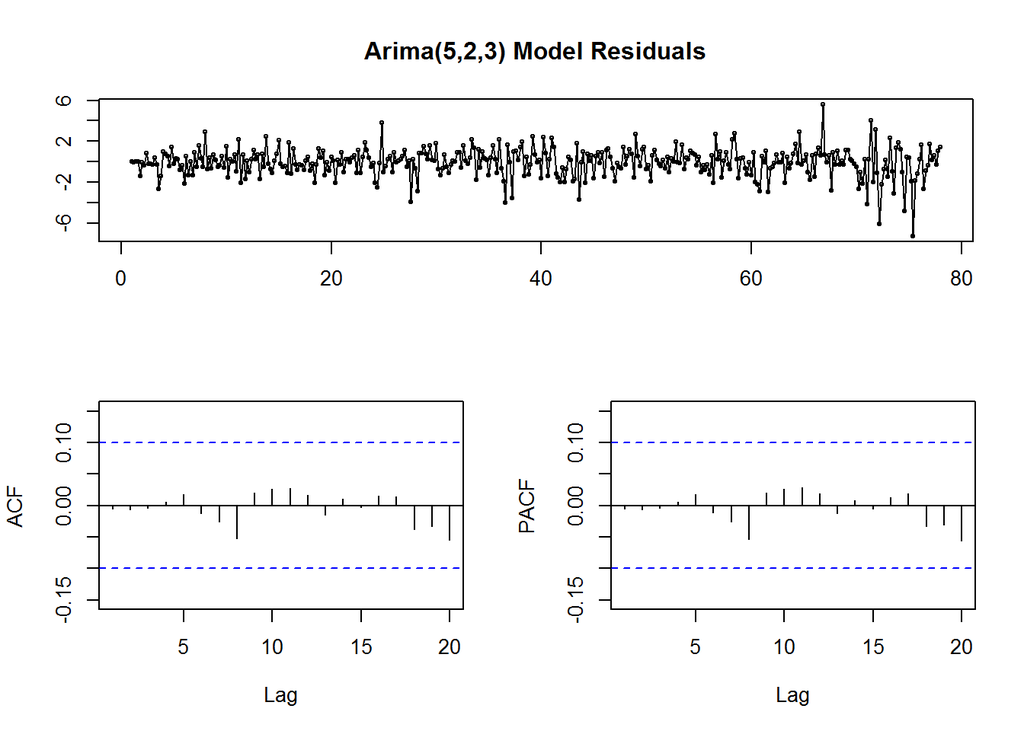

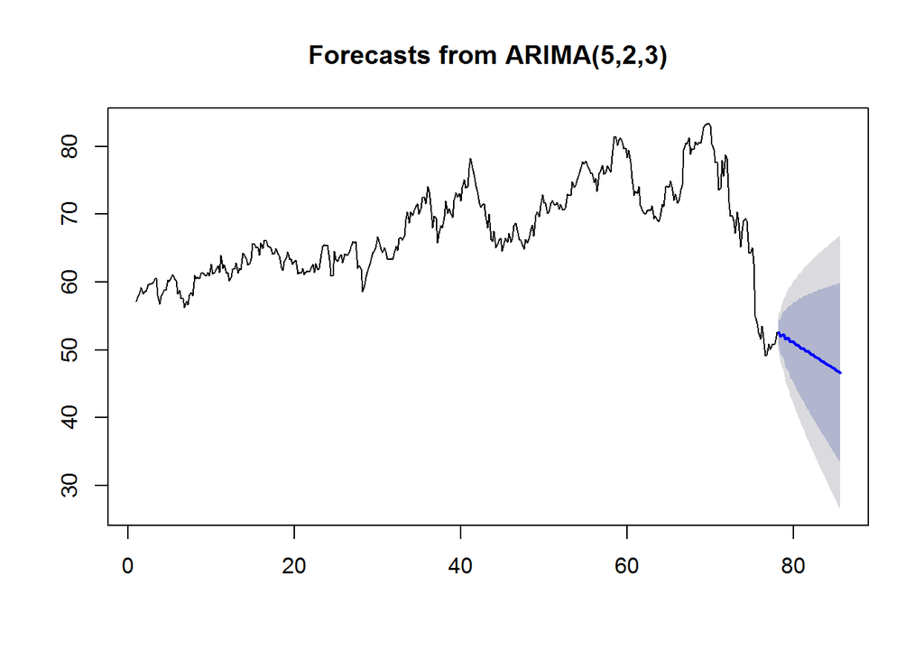

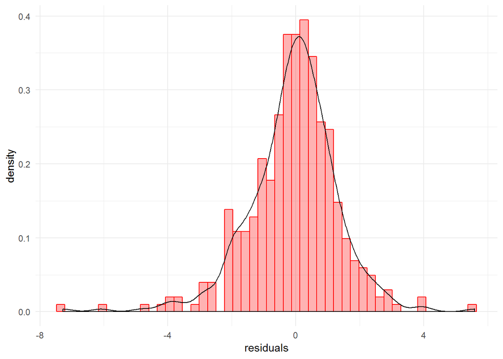

```r
ggplot(data.frame(residuals = residuals(fit_test)), aes(x =residuals)) + geom_histogram(bins = 50, aes(y = ..density..), col = "red", fill = "red", alpha = 0.3) + geom_density()
```

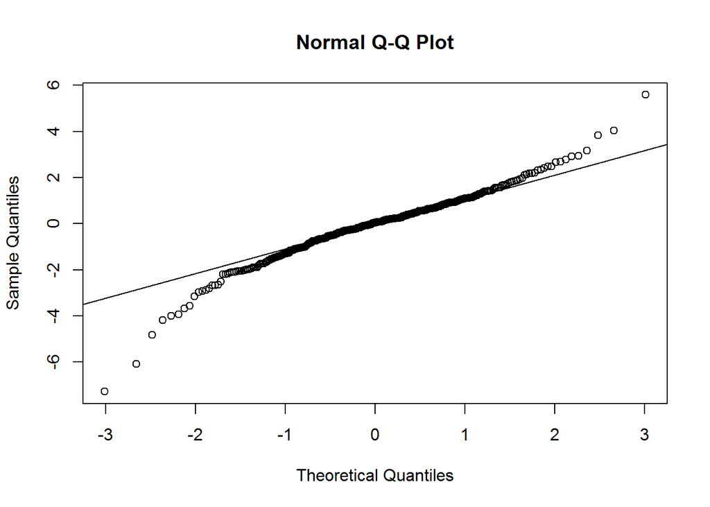

```r
qqnorm(residuals(fit_test))
qqline(residuals(fit_test))
```

```
##
## Call:
## arima(x = ATVI_ts[, 4], order = c(6, 2, 3))
##
## Coefficients:
##           ar1      ar2     ar3     ar4     ar5     ar6      ma1      ma2
##       -0.8164  -0.8072  0.0499  0.0627  0.0266  0.0239  -0.1918  -0.0414
## s.e.   0.2956   0.1943  0.0835  0.0850  0.0784  0.0756   0.2913   0.2218
##           ma3
##       -0.7446
## s.e.   0.1771
##
## sigma^2 estimated as 1.96:  log likelihood = -676.18,  aic = 1372.36
```

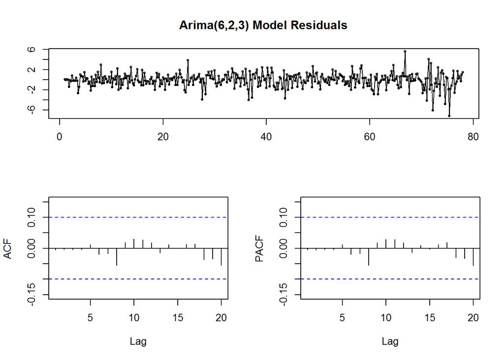

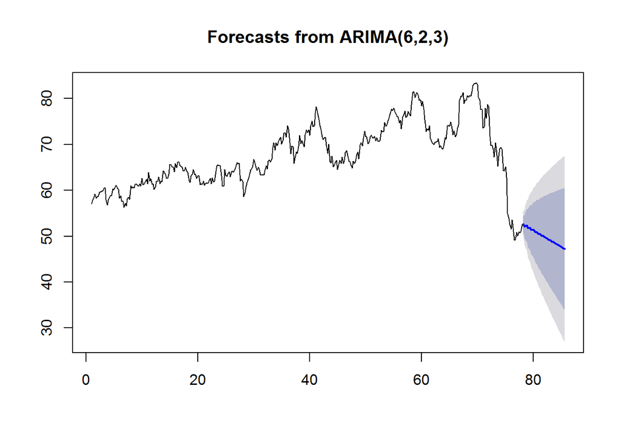

```
##
## Call:
## arima(x = ATVI_ts[, 4], order = c(8, 2, 3))
##
## Coefficients:
##           ar1      ar2     ar3     ar4     ar5     ar6      ar7      ar8
##       -0.5579  -0.4295  0.0655  0.0512  0.0005  0.0271  -0.0061  -0.0842
## s.e.   0.4799   0.4475  0.0712  0.0765  0.0843  0.0682   0.0720   0.0768
##           ma1      ma2      ma3
##       -0.4505  -0.1581  -0.3713
## s.e.   0.4812   0.3234   0.4393
##
## sigma^2 estimated as 1.954:  log likelihood = -675.57,  aic = 1375.15
```

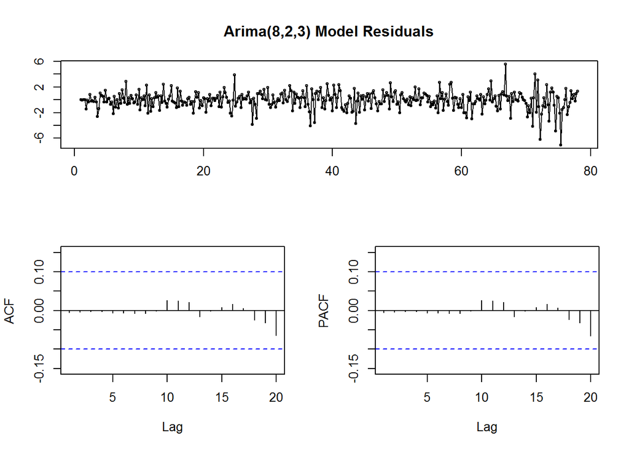

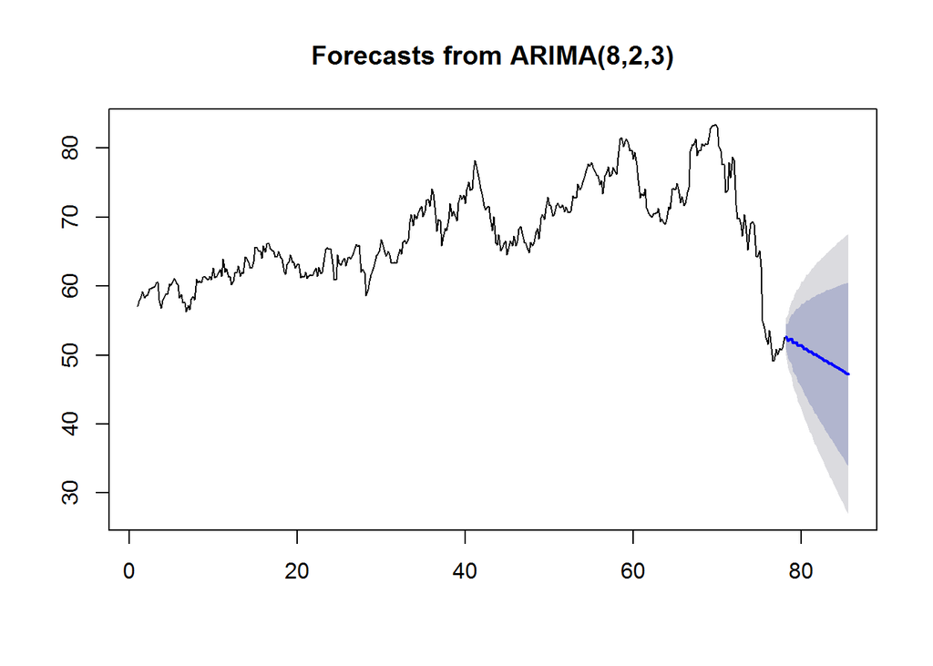

| Arima_Model | AIC |
| --- | --- |
| (3,2,1) | 1369.226 |
| (5,2,3) | 1370.461 |
| (6,2,3) | 1372.360 |
| (8,2,3) | 1375.150 |

The Akaike information criterion (AIC) is an estimator of the relative quality of the model for the given data. From the table, the arima(3,2,1) model performed the best in reduction of information loss; however there is no substantial difference between the models as the AIC’s are not relatively different from each other.